# Part II - Ford GoBike Data Exploration

## by Josh Iden

## Investigation Overview

The Ford GoBike dataset provides key information about the bike sharing service in the San Francisco market for February 2019. The purpose of this analysis is to identify key rider trends and the popularity and characteristics of ridership.

## Dataset Overview

The dataset consisted of 183,412 rows and 16 columns. Features included in this dataset:

- Duration of ride
- Start Time
- End Time
- Start Station & Location (Latitude & Longitude)
- End Station & Location (Latitude & Longitude)
- User Type (Subscriber or Customer)
- Member Birth Year
- Member Gender

## Distribution of Rides By Day

Over the month of February 2019, weekdays are significantly more popular than the weekends - the only exception being February 13, which upon investigation, turned out to have rained all day! (source: [timeanddate.com](https://www.timeanddate.com/weather/usa/san-francisco/historic?month=2&year=2019))

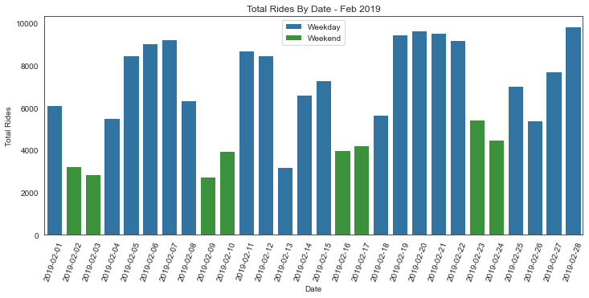

## Average Speed By Age Group

Riders in their 30s and 40s tend to ride fastest, followed by riders in their 20s and 50s.

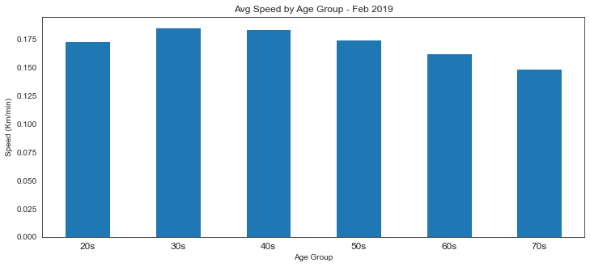

## Average Age of Riders During the Week and Weekend

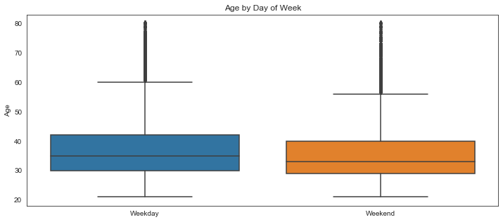

## Summary of Key Insights

Ridership is nearly twice as high on weekdays than on weekends Riders in their 30s and 40s tend to ride fastest on average Riders on average are older during weekdays than on weekends, supporting the conclusion that ridership is largely based on workers commuting to work or other weekday commitments than for pleasure.